# Türkiye 2000 ve 2016 Nüfus Verileri ve Grafikleri

Bu proje Hakan Akmanoğlu ve Burak Demir tarafından hazırlanmıştır.

*30 Ocak 2018*

### Bu proje kapsamında lazım olan kütüphaneleri aşağıdaki kodlar aracılığıyla indirdik.

```r
library(dplyr)
library(ggplot2)
library(knitr)
```

## 2016 Yılında Türkiye’nin İllere Göre Nüfusu

```r
#butun iller ve nufusu grafik
setwd("/Users/hakma/Desktop/Proje")
veri=read.table("nufus1.csv",header=TRUE,sep=";")
knitr::kable(veri)
```

| il | ERKEK_2016 | KADIN_2016 | NUFUS_2000 | NUFUS_2016 | ORAN | BOLGE |
| --- | --- | --- | --- | --- | --- | --- |
| Adana | 1101340 | 1100330 | 1849478 | 2201670 | 19 | Akdeniz |
| Adiyaman | 307662 | 302822 | 623811 | 610484 | -2 | Guneydogu |
| Afyonkarahisar | 354458 | 360065 | 812416 | 714523 | -12 | Ege |
| Agri | 281389 | 260866 | 528744 | 542255 | 3 | Doguanadolu |
| Aksaray | 197362 | 199311 | 396084 | 396673 | 0 | Icanadolu |
| Amasya | 161555 | 164796 | 365231 | 326351 | -11 | Karadeniz |
| Ankara | 2653431 | 2693087 | 4007860 | 5346518 | 33 | Icanadolu |
| Antalya | 1174936 | 1153619 | 2322941 | 2328555 | 0 | Akdeniz |
| Ardahan | 50884 | 47451 | 133756 | 98335 | -26 | Doguanadolu |
| Artvin | 84597 | 83471 | 191934 | 168068 | -12 | Karadeniz |
| Aydin | 533004 | 535256 | 950757 | 1068260 | 12 | Ege |
| Balikesir | 596896 | 599280 | 1076347 | 1196176 | 11 | Marmara |
| Bartin | 95131 | 97258 | 184178 | 192389 | 4 | Karadeniz |
| Batman | 290479 | 286420 | 456734 | 576899 | 26 | Doguanadolu |
| Bayburt | 46182 | 43972 | 97358 | 90154 | -7 | Icanadolu |
| Bilecik | 114189 | 104108 | 194326 | 218297 | 12 | Marmara |
| Bingol | 137588 | 131972 | 253739 | 269560 | 6 | Doguanadolu |
| Bitlis | 177088 | 164137 | 388678 | 341225 | -12 | Doguanadolu |
| Bolu | 148481 | 151415 | 270654 | 299896 | 11 | Karadeniz |
| Burdur | 130082 | 131319 | 256803 | 261401 | 2 | Akdeniz |
| Bursa | 1454059 | 1447337 | 2125140 | 2901396 | 37 | Marmara |
| canakkale | 262288 | 257505 | 464975 | 519793 | 12 | Marmara |
| cankiri | 91874 | 92006 | 270355 | 183880 | -32 | Icanadolu |
| corum | 261606 | 266257 | 597065 | 527863 | -12 | Karadeniz |
| Denizli | 500398 | 505289 | 850029 | 1005687 | 18 | Ege |
| Diyarbakir | 844011 | 829108 | 1908691 | 1673119 | -12 | Guneydogu |
| Duzce | 185775 | 184596 | 314266 | 370371 | 18 | Karadeniz |
| Edirne | 203738 | 197963 | 402606 | 401701 | 0 | Marmara |
| Elazig | 287991 | 290798 | 569616 | 578789 | 2 | Doguanadolu |
| Erzincan | 114075 | 111957 | 316841 | 226032 | -29 | Doguanadolu |

[output cut: 51 more lines]

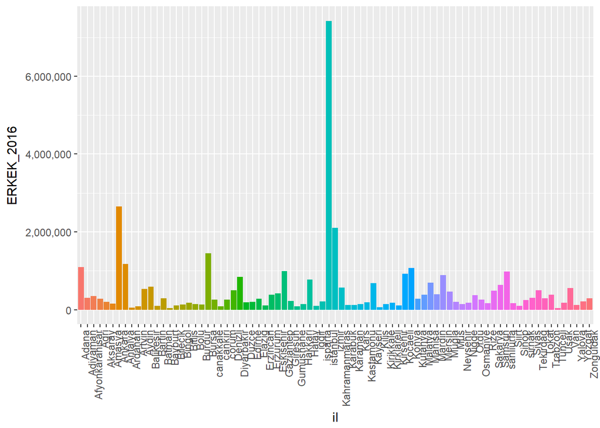

```r
ggplot(veri,aes(x=il,y=ERKEK_2016))+geom_bar(stat = "identity",aes(fill=il)) + theme(legend.position = "none")+theme(axis.text.x = element_text(angle = 90, hjust = 1))+scale_y_continuous(label=scales::comma)
```

2016 Yılında yapılan nüfus sayımları sonucunda belirlenen erkek nüfus sayısını hem .csv formatında hemde grafiksel gösterimini gösterir. Buradan illere göre ne kadar asker alınması hakkında bilgi sağlanabilir.

## 2016 Yılında Türkiye’de Bir Milyondan Fazla Olan İller

```r
##nufusu 1 milyondan fazla ola iller
# veri %>%
#   arrange(desc(NUFUS_2016))
# veri %>%
#   filter(NUFUS_2016>1000000)
birmilyon=veri %>%
  filter(NUFUS_2016>1000000)
knitr::kable(birmilyon)
```

| il | ERKEK_2016 | KADIN_2016 | NUFUS_2000 | NUFUS_2016 | ORAN | BOLGE |
| --- | --- | --- | --- | --- | --- | --- |
| Adana | 1101340 | 1100330 | 1849478 | 2201670 | 19 | Akdeniz |
| Ankara | 2653431 | 2693087 | 4007860 | 5346518 | 33 | Icanadolu |
| Antalya | 1174936 | 1153619 | 2322941 | 2328555 | 0 | Akdeniz |
| Aydin | 533004 | 535256 | 950757 | 1068260 | 12 | Ege |
| Balikesir | 596896 | 599280 | 1076347 | 1196176 | 11 | Marmara |
| Bursa | 1454059 | 1447337 | 2125140 | 2901396 | 37 | Marmara |
| Denizli | 500398 | 505289 | 850029 | 1005687 | 18 | Ege |
| Diyarbakir | 844011 | 829108 | 1908691 | 1673119 | -12 | Guneydogu |
| Gaziantep | 998926 | 975318 | 1285249 | 1974244 | 54 | Guneydogu |
| Hatay | 780854 | 774311 | 1253726 | 1555165 | 24 | Marmara |
| istanbul | 7424390 | 7379726 | 10018735 | 14804116 | 48 | Marmara |
| izmir | 2104632 | 2118913 | 3370866 | 4223545 | 25 | Ege |
| Kahramanmaras | 565816 | 546818 | 1002384 | 1112634 | 11 | Guneydogu |
| Kayseri | 681269 | 677711 | 1060432 | 1358980 | 28 | Icanadolu |
| Kocaeli | 927157 | 903615 | 1401784 | 1830772 | 31 | Marmara |
| Konya | 1073631 | 1087672 | 2192166 | 2161303 | -1 | Icanadolu |
| Manisa | 701094 | 695851 | 1260169 | 1396945 | 11 | Ege |
| Mersin | 885583 | 888269 | 1651400 | 1773852 | 7 | Akdeniz |
| Samsun | 640699 | 655228 | 1572317 | 1295927 | -18 | Karadeniz |
| sanliurfa | 976938 | 963689 | 1443422 | 1940627 | 34 | Guneydogu |
| Van | 561592 | 538598 | 877524 | 1100190 | 25 | Doguanadolu |

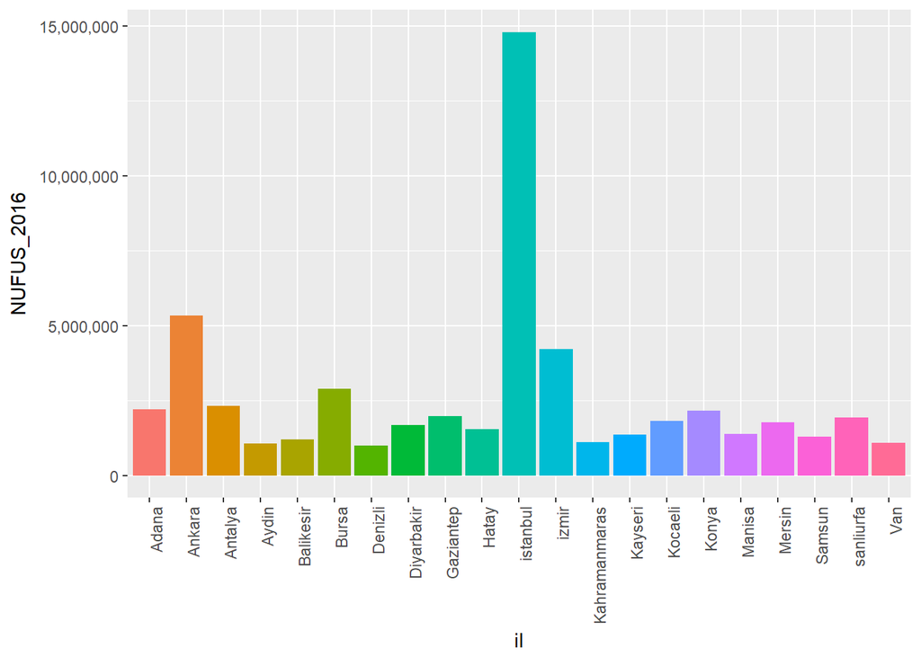

```r
ggplot(birmilyon,aes(x=il,y=NUFUS_2016))+geom_bar(stat = "identity",aes(fill=il)) + theme(legend.position = "none")+theme(axis.text.x = element_text(angle = 90, hjust = 1))+scale_y_continuous(label=scales::comma)
```

2016 yılında, son düzenlemelere göre bir ilin büyükşehir belediyesi olabilmesi için nüfus barajı 1 milyon olarak belirlenmiştir. Bu maddeyi geçebilen şehirleri gösteren grafiksel gösterimidir.

## 2016 Yılında Nüfusu En Fazla Olan İller

```r
#nufusu en fazla olan 10 il
nufus=veri %>%
  arrange(desc(NUFUS_2016)) %>% slice(1:10)
knitr::kable(nufus)
```

| il | ERKEK_2016 | KADIN_2016 | NUFUS_2000 | NUFUS_2016 | ORAN | BOLGE |
| --- | --- | --- | --- | --- | --- | --- |
| istanbul | 7424390 | 7379726 | 10018735 | 14804116 | 48 | Marmara |
| Ankara | 2653431 | 2693087 | 4007860 | 5346518 | 33 | Icanadolu |
| izmir | 2104632 | 2118913 | 3370866 | 4223545 | 25 | Ege |
| Bursa | 1454059 | 1447337 | 2125140 | 2901396 | 37 | Marmara |
| Antalya | 1174936 | 1153619 | 2322941 | 2328555 | 0 | Akdeniz |
| Adana | 1101340 | 1100330 | 1849478 | 2201670 | 19 | Akdeniz |
| Konya | 1073631 | 1087672 | 2192166 | 2161303 | -1 | Icanadolu |
| Gaziantep | 998926 | 975318 | 1285249 | 1974244 | 54 | Guneydogu |
| sanliurfa | 976938 | 963689 | 1443422 | 1940627 | 34 | Guneydogu |
| Kocaeli | 927157 | 903615 | 1401784 | 1830772 | 31 | Marmara |

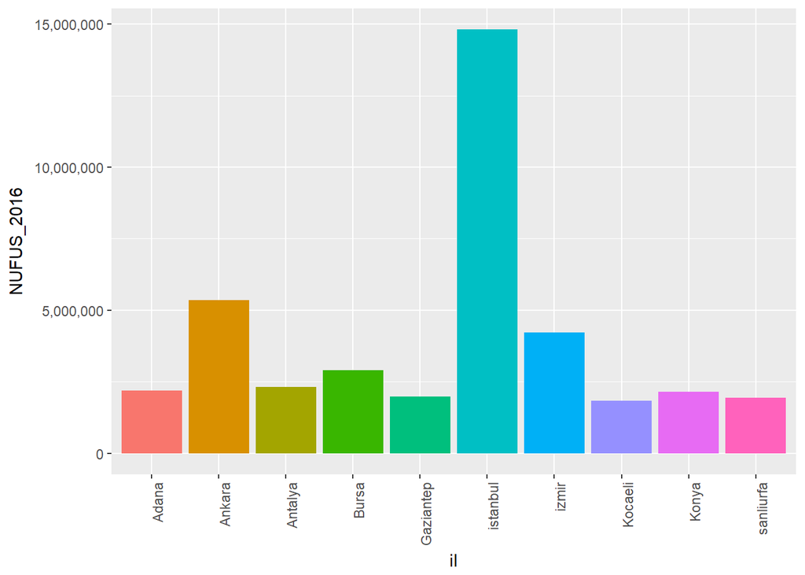

```r
ggplot(nufus,aes(x=il,y=NUFUS_2016))+geom_bar(stat="identity",aes(fill=il))+theme(legend.position = "none")+theme(axis.text.x=element_text(angle=90,hjust=1))+scale_y_continuous(label=scales::comma)
```

2016 yılında en fazla nüfusa sahip 10 il, hangi şehire ne kadar elektrik,su ve doğalgaz gibi temel ihtiyaçların sağlanmasında öncelik tanınabilir.

## 2000-2016 Yılları Arası Nüfus Artış Oranı En Fazla Olan 10 İl

```r
#nufus artıs oranı en fazla olan 10 il
oran2=veri%>%
  arrange(desc(ORAN))%>%slice(1:10)
knitr::kable(oran2)
```

| il | ERKEK_2016 | KADIN_2016 | NUFUS_2000 | NUFUS_2016 | ORAN | BOLGE |
| --- | --- | --- | --- | --- | --- | --- |
| Tekirdag | 499819 | 473056 | 623591 | 972875 | 56 | Marmara |
| Gaziantep | 998926 | 975318 | 1285249 | 1974244 | 54 | Guneydogu |
| istanbul | 7424390 | 7379726 | 10018735 | 14804116 | 48 | Marmara |
| Yalova | 120605 | 121060 | 168593 | 241665 | 43 | Marmara |
| Bursa | 1454059 | 1447337 | 2125140 | 2901396 | 37 | Marmara |
| sirnak | 251392 | 232396 | 353197 | 483788 | 37 | Doguanadolu |
| sanliurfa | 976938 | 963689 | 1443422 | 1940627 | 34 | Guneydogu |
| Ankara | 2653431 | 2693087 | 4007860 | 5346518 | 33 | Icanadolu |
| Kocaeli | 927157 | 903615 | 1401784 | 1830772 | 31 | Marmara |
| Mugla | 470404 | 453369 | 715328 | 923773 | 29 | Ege |

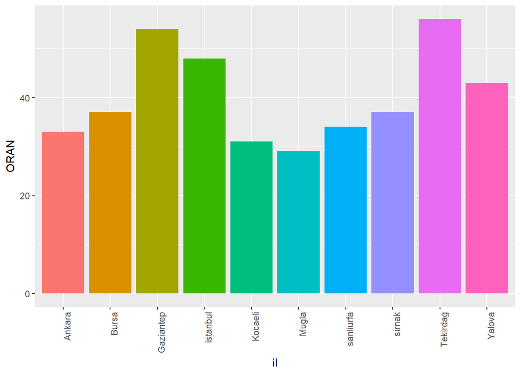

```r
ggplot(oran2,aes(x=il,y=ORAN))+geom_bar(stat="identity",aes(fill=il))+theme(legend.position = "none")+theme(axis.text.x=element_text(angle=90,hjust=1))+scale_y_continuous(label=scales::comma)
```

Yıllara göre nüfus artışı en fazla 10 ilde bulunan insanların nüfus artış nedenlerini araştırmak için hangi illerden başlanması gerektiğine bilgi sağlar. Bu artış sebeplerinin göç yoluylamı yoksa doğum yoluylamı sağlandığı araştırılabilir. Ve ona göre önlem alınabilir.

## 2000-2016 Yılları Arası Bölgelere Göre Nüfus Artış Sayısı

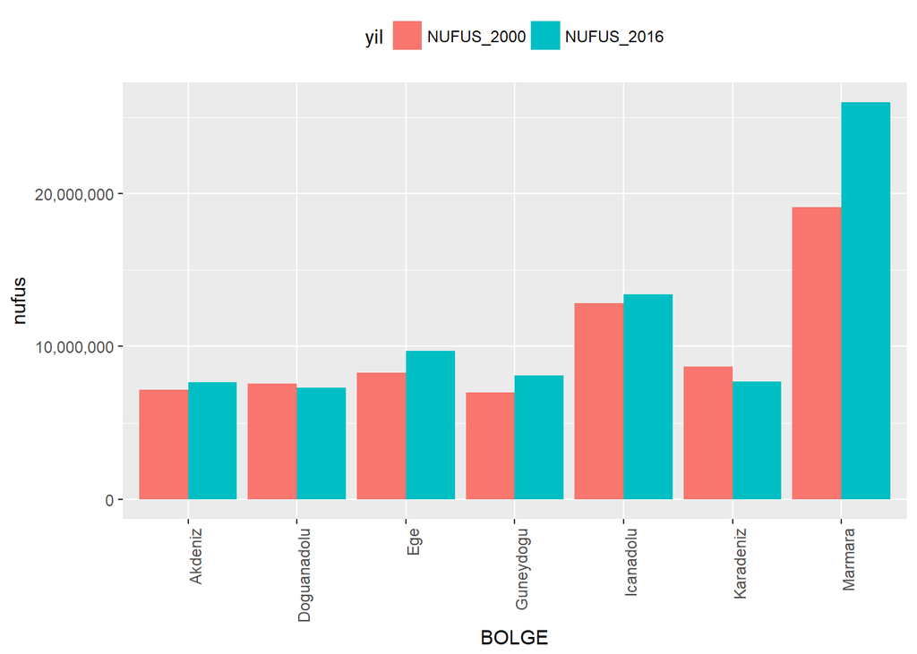

```r
#bölgelere göre nufus artıs nufus
veri %>% group_by(BOLGE) %>% summarise_at(vars(NUFUS_2000,NUFUS_2016),funs(sum)) %>% tidyr::gather(yil,nufus,-BOLGE) %>%
    ggplot(.,aes(x=BOLGE,y=nufus,group=yil))+geom_bar(stat="identity",position ="dodge",aes(fill=yil))+theme(legend.position = "top")+theme(axis.text.x=element_text(angle=90,hjust=1))+scale_y_continuous(label=scales::comma)
```

Hangi bölgeler ne kadar sayısal olarak artış gösterdi? Bunun sonucunda hangi bölgeler kalabalıklaştı. Ve metre kare başına düşen insan sayısını hesaplayarak, insanların yaşam kalitesini arttırmak için teşvikler verilebilir.

## 2000-2016 Yılları Arası Bölgelere Nüfus Artış Oranı

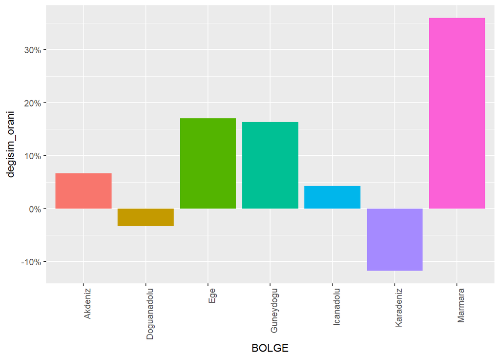

```r
#bolgelere göre nufus artıs oranı
veri %>% group_by(BOLGE) %>% summarise_at(vars(NUFUS_2000,NUFUS_2016),funs(sum)) %>% mutate(degisim_orani=(NUFUS_2016/NUFUS_2000-1)) %>%
  ggplot(.,aes(x=BOLGE,y=degisim_orani))+geom_bar(stat="identity",aes(fill=BOLGE))+theme(legend.position = "none")+theme(axis.text.x=element_text(angle=90,hjust=1))+scale_y_continuous(label=scales::percent)
```

Ülkede bölgelere göre nufus artış oranını görerek oranı düşük olan ve oranı negatif olan yani nufus kaybeden bölgeleri belirleyip, devletbu alanlara yatırımlar ve projeler yaparak oraya göçü ve nufusu arttırmaya yönelik politikalar izleyebilir. Ülkede hangi bölgelere göç daha fazla olmuş hangi bölgelerin yatırıma yeniliğe ihtiyacı var gibi durumlar görülebilir.Ayrıca yatırımcılara bir fikir oluşturmak amacıyla nufus artıs oranı fazla olan illeri belirleyip bu orana etkı eden tıcarı ve sosyal durumları belirleyerek oran az olan bölgelere yatırım yapıp insanları o bölgeye cekip göç kaynagı olabilir.

```r
#nufus artıs oranı en az olan 10 il
oran2=veri%>%
  arrange((ORAN))%>%slice(1:10)
knitr::kable(oran2)
```

| il | ERKEK_2016 | KADIN_2016 | NUFUS_2000 | NUFUS_2016 | ORAN | BOLGE |
| --- | --- | --- | --- | --- | --- | --- |
| Erzurum | 381138 | 380883 | 1298624 | 762021 | -41 | Doguanadolu |
| Yozgat | 210600 | 210441 | 682919 | 421041 | -38 | Icanadolu |
| cankiri | 91874 | 92006 | 270355 | 183880 | -32 | Icanadolu |
| Erzincan | 114075 | 111957 | 316841 | 226032 | -29 | Doguanadolu |
| Eskisehir | 421580 | 423262 | 1188802 | 844842 | -29 | Icanadolu |
| Kirikkale | 140085 | 137899 | 383508 | 277984 | -28 | Icanadolu |
| Tokat | 299262 | 303400 | 828027 | 602662 | -27 | Karadeniz |
| Ardahan | 50884 | 47451 | 133756 | 98335 | -26 | Doguanadolu |
| Trabzon | 385009 | 394370 | 975137 | 779379 | -20 | Karadeniz |
| Samsun | 640699 | 655228 | 1572317 | 1295927 | -18 | Karadeniz |

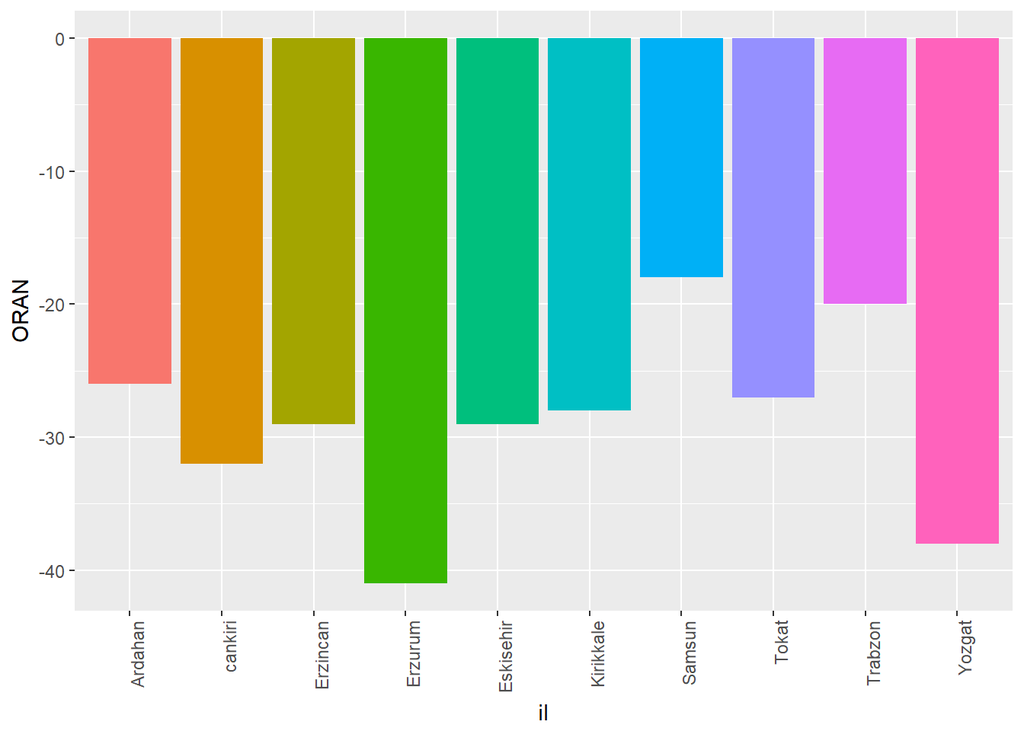

```r
ggplot(oran2,aes(x=il,y=ORAN))+geom_bar(stat="identity",aes(fill=il))+theme(legend.position = "none")+theme(axis.text.x=element_text(angle=90,hjust=1))+scale_y_continuous(label=scales::comma)
```

Bu grafikte nüfus artış oranı en az olan(negatif olan) yani nufus kaybeden illeri görerek bu illerin nufusunun artması için bu illere ne gibi yatırımlar, projeler yapılmalı insanları buraya göç etmeye cekecek durumlar ve insanların buradan göç etme nedenlerini araştırarak ona göre kararlar alınabilir.